# Calibration: Isotope Data

Source file: [SI GitHub Repository](http://www.github.com/KopfLab/2018_Silverman_et_al/) / isotope_calibration.Rmd

Silverman et al.

05 Jul 2018

```r
library(tidyverse) # dplyr, tidyr, ggplot
library(isoreader) # reading isotope data files
library(isoprocessor) # processing isotope data
library(readxl) # reading excel file
library(openxlsx) # writing excel file
library(knitr) # generating reports
source(file.path("lib", "functions.R"))
opts_chunk$set(
  collapse = TRUE, comment = "#>",
  dev=c("png", "pdf"), dev.args=list(pdf = list(encoding="WinAnsi", useDingbats=FALSE)),
  fig.keep="all", fig.path=file.path("figures", "2018_Silverman_et_al-"))
```

Processed using the pre-release packages [isoreader](http://isoreader.kopflab.org) version 0.9.19.9000 and [isoprocessor](http://isoprocessor.kopflab.org/) version 0.2.6.9000. To install the exact same versions from the time of writing, run `devtools::install_github("Kopflab/isoreader", ref = "v2018_Silverman")` and `devtools::install_github("Kopflab/isoprocessor", ref = "v2018_Silverman")`, respectively.

# 1 Biomass $\delta^{15}N$

Biomass nitrogen isotopic composition was measured on an EA-IRMS as described in the methods section of the manuscript. The following code steps through the data processing and calibration to convert measured values to values vs. the international reference standard (Air N2).

## 1.1 Load EA-IRMS data

```r
isofiles <-
  file.path(
    "data",
    c("2018_Silverman_et_al-isotope_data_cylindrica.cf.rda",
      "2018_Silverman_et_al-isotope_data_variabilis.cf.rda")
  ) %>%
  iso_read_continuous_flow()
```

## 1.2 Chromatograms

Display chromatograms of the standards.

```
#> Info: applying file filter, keeping 57 of 111 files
#> Info: calculating ratio(s) in 57 data file(s): 29/28
```

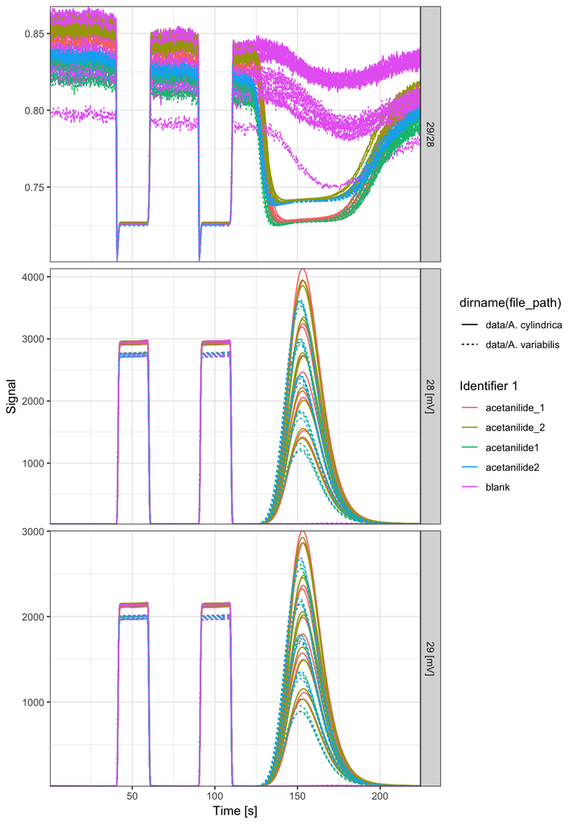

```r
isofiles %>%
  # select blanks and standards for chromatograms
  iso_filter_files(
    `Identifier 1` %in%
      c("blank", "acetanilide_1", "acetanilide_2", "acetanilide1", "acetanilide2")) %>%
  # calculate 29/28 ratio
  iso_calculate_ratios("29/28") %>%
  iso_plot_continuous_flow_data(
    data = c("29/28", "28", "29"),
    color = `Identifier 1`,
    linetype = dirname(file_path)
  )
```

## 1.3 Data Table

Retrieve the data table.

```r
# aggregate data table
data <- isofiles %>%
  # retrieve vendor data
  iso_get_vendor_data_table(
    select =
      c(ref_used = `Is Ref.?`, Start, Rt, End,
        `Ampl 28`, `Intensity All`, `rR 29N2/28N2`, `d 15N/14N`),
    include_file_info =
      c(datetime = file_datetime, run = file_path, Analysis, Row,
        name = `Identifier 1`, amount.mg = `Identifier 2`)
  )  %>%
  # before peak jump
  filter(Rt < 200) %>%
  # updates
  mutate(
    # run = last part of directory name for simplicity
    run = basename(dirname(run)),
    # convert to numbers
    amount.mg = parse_number(amount.mg),
    # correct nomenclature between the two runs
    name = case_when(
      name == "acetanilide_1" ~ "acetanilide1",
      name == "acetanilide_2" ~ "acetanilide2",
      TRUE ~ name),
    # introduce type column
    type = case_when(
      str_detect(name, "acetanilide") ~ "standard",
      str_detect(name, "[Ee]mpty") ~ "empty",
      str_detect(name, "blank") ~ "blank",
      TRUE ~ "sample")
  )
```

```
#> Info: aggregating vendor data table without units from 111 data file(s), including file info 'c(datetime = file_datetime, run = file_path, Analysis, Row, name = `Identifier 1`,
#>     amount.mg = `Identifier 2`)'
```

```r
## map peaks
peak_map <- data_frame(
  compound = "N2",
  is_ref_peak = c(TRUE, TRUE, FALSE),
  `Rt:EA1` = c(50, 100, 155)
)
peak_map
```

| compound | is_ref_peak | Rt:EA1 |
| --- | --- | --- |
| N2 | TRUE | 50 |
| N2 | TRUE | 100 |
| N2 | FALSE | 155 |

```r
# map peaks
data_w_peaks <- data %>%
  # specify peak map
  mutate(map_id = "EA1") %>%
  iso_map_peaks(peak_map, file_id = file_id, map_id = map_id,
                rt = Rt, rt_start = Start, rt_end = End)
# problematic peaks
data_w_peaks %>%
  iso_get_problematic_peaks(select = c(file_id, compound, Start, Rt, End))
```

```
#> Info: fetching 0 of 313 data table entries with problematic peak identifications (unidentified, missing or ambiguous)
```

| file_id | compound | Start | Rt | End | problem |
| --- | --- | --- | --- | --- | --- |

```r
# focus on non problematic peaks only
data_w_peaks <- data_w_peaks %>% iso_remove_problematic_peaks()
```

```
#> Info: removing 0 of 313 data table entries because of problematic peak identifications (unidentified, missing or ambiguous)
```

```r
# reference peaks
data_ref_peaks <- data_w_peaks %>% filter(is_ref_peak)

# analyte peaks
data_analyte_peaks <- data_w_peaks %>% filter(!is_ref_peak)
```

## 1.4 Reference peaks

Reference peaks show no significant variation between the pre- and post-analyte peak reference square peaks.

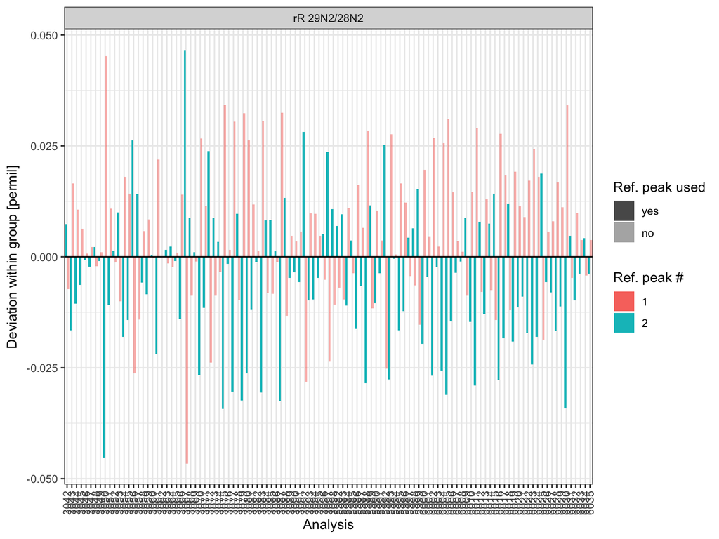

```r
data_ref_peaks %>%
  iso_plot_ref_peaks(
    is_ref_condition = is_ref_peak,
    ratio = c(`rR 29N2/28N2`),
    group_id = Analysis,
    within_group = TRUE,
    is_ref_used = ref_used
  )
```

# 2 Data Processing

## 2.1 Signal Yield

Signal intensity is properly linear vs. standard weights but yield (slope) is slightly different between the two analytical runs, which is not surprising since they were months apart and signal dilution was not exactly the same.

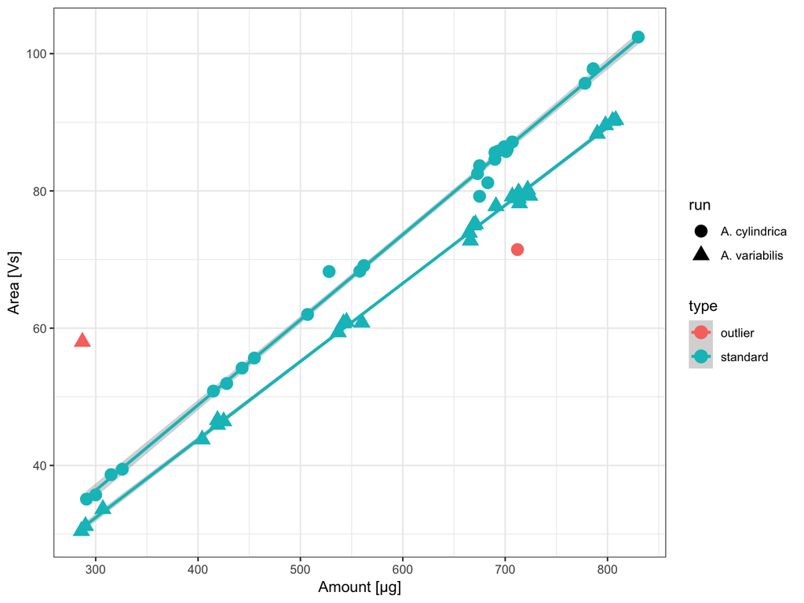

```r
# identifying two outliers that were mis-weighed
data_analyte_peaks <- data_analyte_peaks %>%
  mutate(type = ifelse(Analysis %in% c("6029", "3066"), "outlier", type))

# visualize calibration standards and rejected outliers
data_analyte_peaks %>%
  filter(type %in% c("standard", "outlier")) %>%
  ggplot() +
  aes(x = 1000*amount.mg, y = `Intensity All`, color = type, shape = run) +
  geom_smooth(data = function(df) filter(df, type == "standard"), method = "lm") +
  geom_point(size = 4) +
  theme_bw() + labs(y = "Area [Vs]", x = "Amount [µg]")
```

## 2.2 Isotopic values

Add known isotope values for standards.

```r
standards <- data_frame(
  name = c("acetanilide1", "acetanilide2"),
  true_d15N = c(1.18, 19.56)
)
standards
```

| name | true_d15N |
| --- | --- |
| acetanilide1 | 1.18 |
| acetanilide2 | 19.56 |

```r
data_w_stds <-
  data_analyte_peaks %>%
  # focus on analytes
  filter(!is_ref_peak) %>%
  # add standard values
  iso_add_standards(standards, match_by = name)
```

```
#> Info: matching standards by 'name' - added 2 standard entries to 40 out of 91 rows
```

## 2.3 Calibration

Evaluate different calibration models across all standards (this combines blank correction, scale contraction, linearity effects and temporal drift and evaluates them all in tandem to gain a better understanding of the individual contributions and relevance).

```r
data_w_calibs <- data_w_stds %>%
  # group by each analytical run
  iso_prepare_for_calibration(group_by = run) %>%
  # run calibrations
  iso_generate_calibration(
    model = c(
      # simple model
      delta_only = lm(`d 15N/14N` ~ true_d15N),
      # multivariate with delta and amplitude
      delta_and_ampl = lm(`d 15N/14N` ~ true_d15N + `Ampl 28`),
      # + the delta and amplitude cross term
      delta_cross_ampl = lm(`d 15N/14N` ~ true_d15N * `Ampl 28`),
      # multivariate with delta and the datetime (i.e. checking for temporal drift)
      delta_and_time = lm(`d 15N/14N` ~ true_d15N + datetime),
      delta_cross_time = lm(`d 15N/14N` ~ true_d15N * datetime),
      # multivariate with delta, amplitude and datetime
      delta_and_ampl_and_time = lm(`d 15N/14N` ~ true_d15N + `Ampl 28` + datetime),
      # multivariate with delta cross amplitude and datetime
      delta_cross_ampl_and_time = lm(`d 15N/14N` ~ true_d15N * `Ampl 28` + datetime)
    ),
    calibration = "d15N",
    is_standard = type == "standard"
  )
```

```
#> Info: preparing data for calibration by grouping based on 'run'
#> Info: generating 'd15N' calibration based on 7 models ('delta_only = lm(`d 15N/14N` ~ true_d15N)', 'delta_and_ampl = lm(`d 15N/14N` ~ true_d15N + `Ampl 28`)', 'delta_cross_ampl = lm(`d 15N/14N` ~ true_d15N * `Ampl 28`)', 'delta_and_time = lm(`d 15N/14N` ~ true_d15N + datetime)', 'delta_cross_time…
```

### 2.3.1 Calibration Parameters

The visualization of the calibration parameters reveals that as expected $^{15}\delta_{true}$ is the most important regressor (the scale contraction), and that the $^{15}\delta_{true} \cdot A_{28}$ and $^{15}\delta_{true} \cdot DT$ cross terms are not statistically significant although the linear intensity term $A_{28}$ is relevant for both analytical runs. Additionally, the *A. cylindrica* run also showing a statistically relevant (`***` = p.value < 0.001) linear drift correction term ($DT$) but no the *A. variabilis* run (no drift). See residuals below for additional information on these multivariate calibration regressions.

```r
# coefficient summary table
data_w_calibs %>% iso_unnest_calibration_parameters("d15N")
```

| run | d15N_calib | d15N_calib_ok | term | estimate | std.error | statistic | p.value | signif | r.squared | adj.r.squared | sigma | statistic1 | p.value1 | df | logLik | AIC | BIC | deviance | df.residual | all_data | d15N_calib_params |
| --- | --- | --- | --- | --- | --- | --- | --- | --- | --- | --- | --- | --- | --- | --- | --- | --- | --- | --- | --- | --- | --- |
| A. cylindrica | delta_only | TRUE | (Intercept) | 2.209569e-01 | 7.894079e-02 | 2.7990206 | 1.186159e-02 | * | 0.9994168 | 0.9993843 | 0.23414738 | 30843.61 | 1.449020e-30 | 2 | 1.710925 | 2.5781502 | 5.56534698 | 0.9868499 | 18 |  |  |
| A. cylindrica | delta_only | TRUE | true_d15N | 1.000556e+00 | 5.697165e-03 | 175.6234912 | 1.449020e-30 | *** | 0.9994168 | 0.9993843 | 0.23414738 | 30843.61 | 1.449020e-30 | 2 | 1.710925 | 2.5781502 | 5.56534698 | 0.9868499 | 18 |  |  |
| A. cylindrica | delta_and_ampl | TRUE | (Intercept) | -2.562643e-01 | 1.298669e-01 | -1.9732848 | 6.494736e-02 | . | 0.9997067 | 0.9996722 | 0.17084489 | 28975.83 | 9.368574e-31 | 3 | 8.586403 | -9.1728057 | -5.18987656 | 0.4961956 | 17 |  |  |
| A. cylindrica | delta_and_ampl | TRUE | true_d15N | 1.000292e+00 | 4.157415e-03 | 240.6043874 | 1.802857e-31 | *** | 0.9997067 | 0.9996722 | 0.17084489 | 28975.83 | 9.368574e-31 | 3 | 8.586403 | -9.1728057 | -5.18987656 | 0.4961956 | 17 |  |  |
| A. cylindrica | delta_and_ampl | TRUE | `Ampl 28` | 1.791098e-04 | 4.368512e-05 | 4.1000186 | 7.466887e-04 | *** | 0.9997067 | 0.9996722 | 0.17084489 | 28975.83 | 9.368574e-31 | 3 | 8.586403 | -9.1728057 | -5.18987656 | 0.4961956 | 17 |  |  |
| A. cylindrica | delta_cross_ampl | TRUE | (Intercept) | -1.598025e-01 | 1.845840e-01 | -0.8657437 | 3.994266e-01 | - | 0.9997166 | 0.9996634 | 0.17312364 | 18812.22 | 1.389880e-28 | 4 | 8.927649 | -7.8552990 | -2.87663762 | 0.4795487 | 16 |  |  |
| A. cylindrica | delta_cross_ampl | TRUE | true_d15N | 9.906658e-01 | 1.358668e-02 | 72.9145081 | 1.291739e-21 | *** | 0.9997166 | 0.9996634 | 0.17312364 | 18812.22 | 1.389880e-28 | 4 | 8.927649 | -7.8552990 | -2.87663762 | 0.4795487 | 16 |  |  |
| A. cylindrica | delta_cross_ampl | TRUE | `Ampl 28` | 1.429517e-04 | 6.567768e-05 | 2.1765650 | 4.483505e-02 | * | 0.9997166 | 0.9996634 | 0.17312364 | 18812.22 | 1.389880e-28 | 4 | 8.927649 | -7.8552990 | -2.87663762 | 0.4795487 | 16 |  |  |
| A. cylindrica | delta_cross_ampl | TRUE | true_d15N:`Ampl 28` | 3.591856e-06 | 4.819579e-06 | 0.7452634 | 4.669201e-01 | - | 0.9997166 | 0.9996634 | 0.17312364 | 18812.22 | 1.389880e-28 | 4 | 8.927649 | -7.8552990 | -2.87663762 | 0.4795487 | 16 |  |  |
| A. cylindrica | delta_and_time | TRUE | (Intercept) | 1.547187e+04 | 5.702338e+03 | 2.7132507 | 1.476081e-02 | * | 0.9995930 | 0.9995451 | 0.20126737 | 20875.83 | 1.519102e-29 | 3 | 5.308839 | -2.6176788 | 1.36525025 | 0.6886454 | 17 |  |  |

[output cut: 40 more lines]

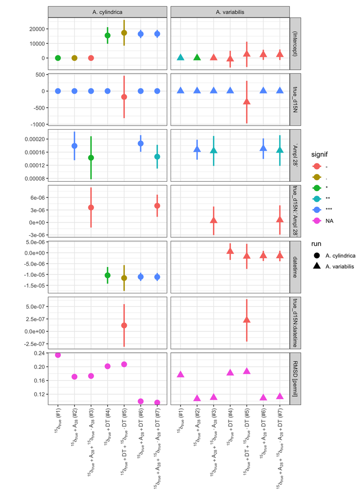

```r
# type-setting calibrations
data_w_calibs <- data_w_calibs %>%
  mutate(
    tex_calib = as_factor(d15N_calib)%>%
      fct_recode(
        "$^{15}\\delta_{true}$ (#1)" = "delta_only",
        "$^{15}\\delta_{true} + A_{28}$ (#2)" = "delta_and_ampl",
        "$^{15}\\delta_{true} + A_{28} + ^{15}\\delta_{true} \\cdot A_{28}$ (#3)" = "delta_cross_ampl",
        "$^{15}\\delta_{true} + DT$ (#4)" = "delta_and_time",
        "$^{15}\\delta_{true} + DT + ^{15}\\delta_{true} \\cdot DT$ (#5)" = "delta_cross_time",
        "$^{15}\\delta_{true} + A_{28} + DT$ (#6)" = "delta_and_ampl_and_time",
        "$^{15}\\delta_{true} + A_{28} + ^{15}\\delta_{true} \\cdot A_{28} + DT$ (#7)" = "delta_cross_ampl_and_time"
      )
  )

# plot to look at coefficients and summary
data_w_calibs %>%
  iso_plot_calibration_parameters(
    calibration = "d15N",
    x = tex_calib,
    shape = run,
    color = signif,
    select_from_summary = c(`RMSD [permil]` = sigma)
  ) +
  scale_x_discrete(labels = latex_labeller) +
  facet_grid(term ~ run, scales = "free_y") +
  labs(x = NULL)
```

A look at the residuals confirms that the calibration that takes both drift and intensity in addition to the $\delta$ value into consideration ($^{15}\delta_{true} + A_{28} + DT$) captures most of the variation in the standards with $^{15}\delta_{true} + A_{28}$ similiarly good for the *A. variabilis* run (i.e. no drift) but not as good for *A. cylindrica* (slight drift effect).

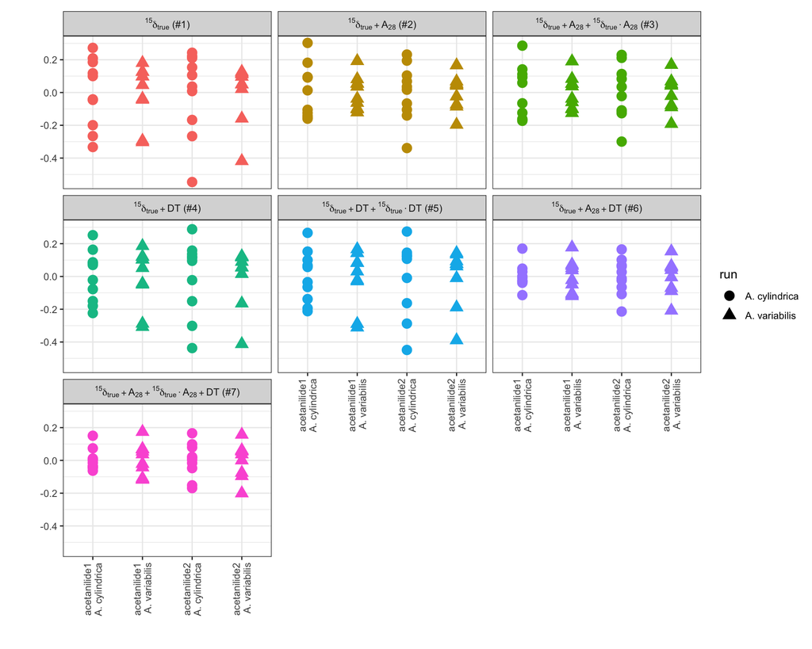

```r
data_w_calibs %>%
  iso_unnest_data(select = everything()) %>%
  filter(type == "standard") %>%
  mutate(name_run = str_c(name, "\n", run)) %>%
  iso_plot_data(
    x = name_run, y = d15N_resid,
    shape = run, color = tex_calib,
    lines = FALSE, points = TRUE
  ) +
  labs(x = "") +
  facet_wrap(~tex_calib, labeller = latex_labeller) +
  guides(color = "none")
```

### 2.3.2 Apply calibrations

```r
data_calibrated <- data_w_calibs %>%
  filter( (run == "A. cylindrica" & d15N_calib == "delta_and_ampl_and_time") | (run == "A. variabilis" & d15N_calib == "delta_and_ampl")) %>%
  iso_apply_calibration(
    predict = true_d15N,
    calibration = "d15N",
    calculate_error = TRUE
  ) %>%
  # unnest the data
  iso_unnest_data()
```

```
#> Info: applying 'd15N' calibration to infer 'true_d15N' for 2 data group(s);
#> storing resulting value in new column 'true_d15N_pred' and estimated error
#> in new column 'true_d15N_pred_se'. This may take a moment...
#> Warning: attributes are not identical across measure variables;
#> they will be dropped
#> finished.
```

### 2.3.3 Inspect calibration results

The comparison of the predicted value in the standards along with the standard error in the prediction (the inherent error of the calibration itself = the analytical precision) provides a measure of how precise the data is.

```r
data_calibrated %>%
  # look only at the standards
  filter(type == "standard") %>%
  # check for each compound (+ other run groupings if appropriate)
  group_by(run, name) %>%
  # generate summary table comparing the
  iso_generate_summary_table(
    raw_d15N = `d 15N/14N`,
    true_d15N,
    # this is the value predicated by the calibration
    d15N_pred = true_d15N_pred,
    # and this is the estimated error based on the calibration
    d15N_error = true_d15N_pred_se
  ) %>%
  select(-true_d15N_sd, -d15N_error_sd)
```

[output not shown]

## 2.4 Final Data

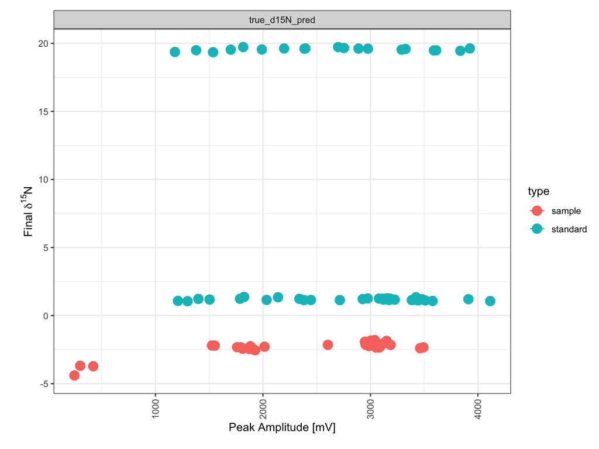

```r
data_calibrated %>%
  filter(type %in% c("sample", "standard")) %>%
  iso_plot_data(
    x = `Ampl 28`,
    y = true_d15N_pred,
    y_error = true_d15N_pred_se,
    color = type,
    points = TRUE,
    lines = FALSE
  ) +
  labs(y = TeX("Final $\\delta^{15}N$"), x = "Peak Amplitude [mV]")
```

## 2.5 Combine with metadata

Resolve the analytical IDs to experimental conditions.

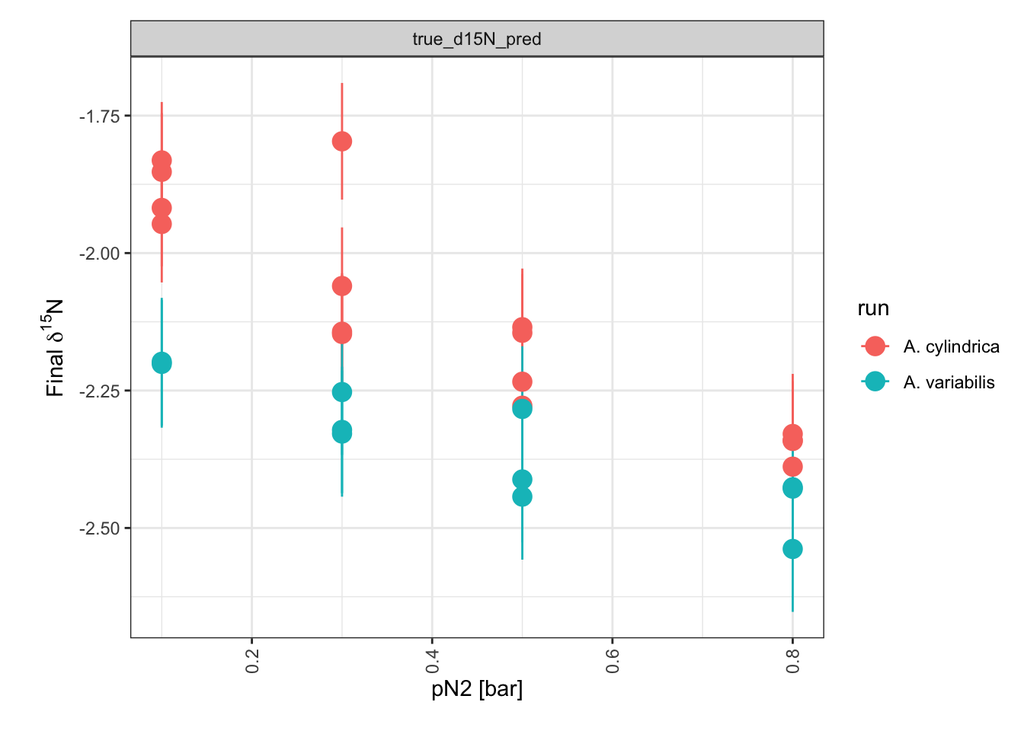

```r
metadata <- read_excel(file.path("data", "2018_Silverman_et_al-isotope_data_sample_metadata.xlsx"))

data_d15N_org <- data_calibrated %>%
  filter(`Ampl 28` > 1000, type == "sample") %>%
  left_join(metadata, by = c("run" = "organism", "name" = "analysis_id"))

# visualize
data_d15N_org %>%
   iso_plot_data(
    x = pN2, y = true_d15N_pred,y_error = true_d15N_pred_se,
    color = run, points = TRUE, lines = FALSE
  ) + labs(y = TeX("Final $\\delta^{15}N$"), x = "pN2 [bar]")
```

# 3 N2 gas $\delta^{15}N$

To calculate fractionation factors, the isotopic composition of the source N2 during nitrogen fixation is equally important and was measured on a Gasbench-IRMS.

## 3.1 Load Gasbench-IRMS data

```r
isofiles <- iso_read_continuous_flow(
  file.path("data","2018_Silverman_et_al-isotope_data_N2_source.cf.rda"))
```

```
#> Info: preparing to read 1 data file(s)...
#> Info: reading file 1/1 'data/2018_Silverman_et_al-isotope_data_N2_source.cf.rda' with '.rda' reader...
#> Info: loaded data for 12 data files from R Data Archive - checking loaded files for content consistency...
```

## 3.2 Chromatograms

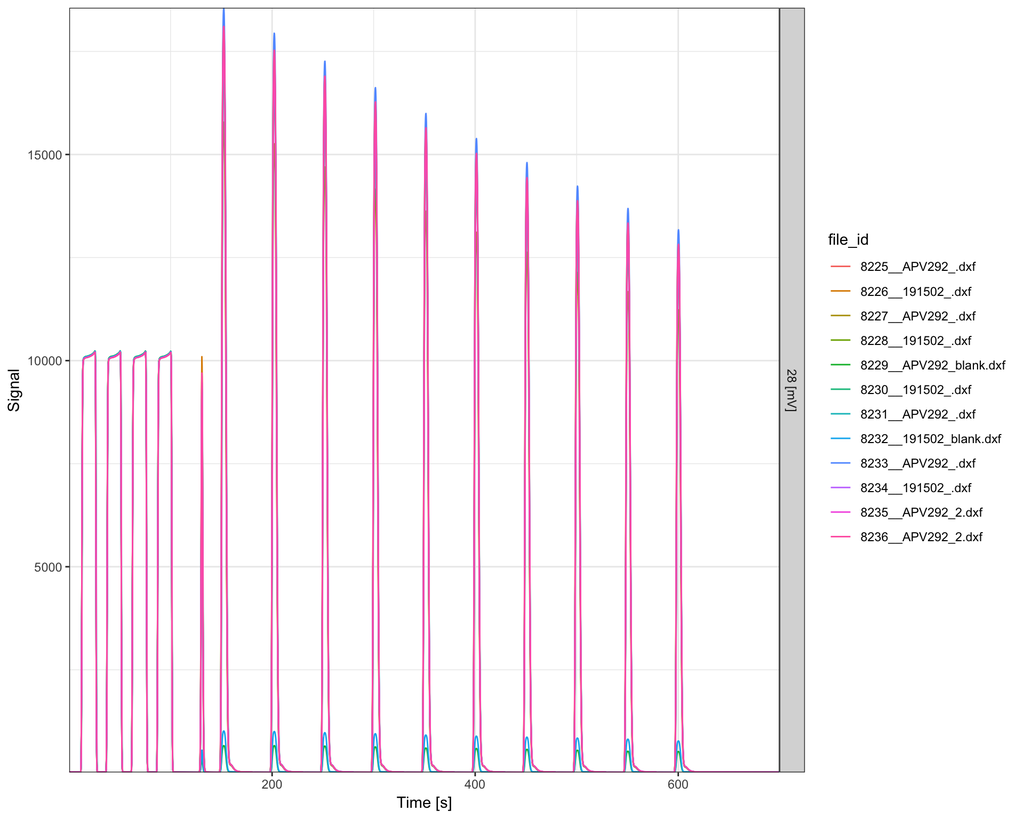

```r
isofiles %>% iso_plot_continuous_flow_data("28")
```

## 3.3 Data Table

```r
data <- isofiles %>%
  # exclude file that required auto-dilution because of too much sample
  iso_get_vendor_data_table(select = c(Rt, `Ampl 28`, `d 15N/14N`), include_file_info = c(file_datetime, Analysis, starts_with("Id"))) %>%
  # correct switched samples on autosampler
  mutate(name = ifelse(Analysis %in% c("8233", "8236"), "191502", ifelse(Analysis == "8234", "APV292", `Identifier 1`))) %>%
  # focus on last analyte peaks
  filter(Rt > 380) %>%
  group_by(Analysis, name, `Identifier 2`) %>%
  summarize_at(vars(`Ampl 28`, `d 15N/14N`), list(mean = mean, sd = sd)) %>%
  arrange(name)
```

```
#> Info: aggregating vendor data table without units from 12 data file(s), including file info 'c(file_datetime, Analysis, starts_with("Id"))'
```

```r
data
```

| Analysis | name | Identifier 2 | Ampl 28_mean | d 15N/14N_mean | Ampl 28_sd | d 15N/14N_sd |
| --- | --- | --- | --- | --- | --- | --- |
| 8226 | 191502 | NA | 13962.6065 | -2.384559 | 865.49973 | 0.01837043 |
| 8228 | 191502 | NA | 13298.5404 | -2.431475 | 815.47858 | 0.02746966 |
| 8230 | 191502 | NA | 13345.2171 | -2.461377 | 829.96150 | 0.01395634 |
| 8232 | 191502 | blank | 824.5526 | -3.389863 | 44.94820 | 0.07363516 |
| 8233 | 191502 | NA | 14242.7989 | -2.362172 | 876.86737 | 0.01866571 |
| 8236 | 191502 | 2 | 13885.4975 | -2.400226 | 872.13437 | 0.02404321 |
| 8225 | APV292 | NA | 13785.4784 | -1.235590 | 826.53610 | 0.01816453 |
| 8227 | APV292 | NA | 12143.4966 | -1.207355 | 746.04888 | 0.01728223 |
| 8229 | APV292 | blank | 538.2140 | -4.367528 | 30.28157 | 0.17235204 |
| 8231 | APV292 | NA | 13235.9841 | -1.264385 | 823.48078 | 0.01874486 |

[output cut: 2 more lines]

## 3.4 Processing

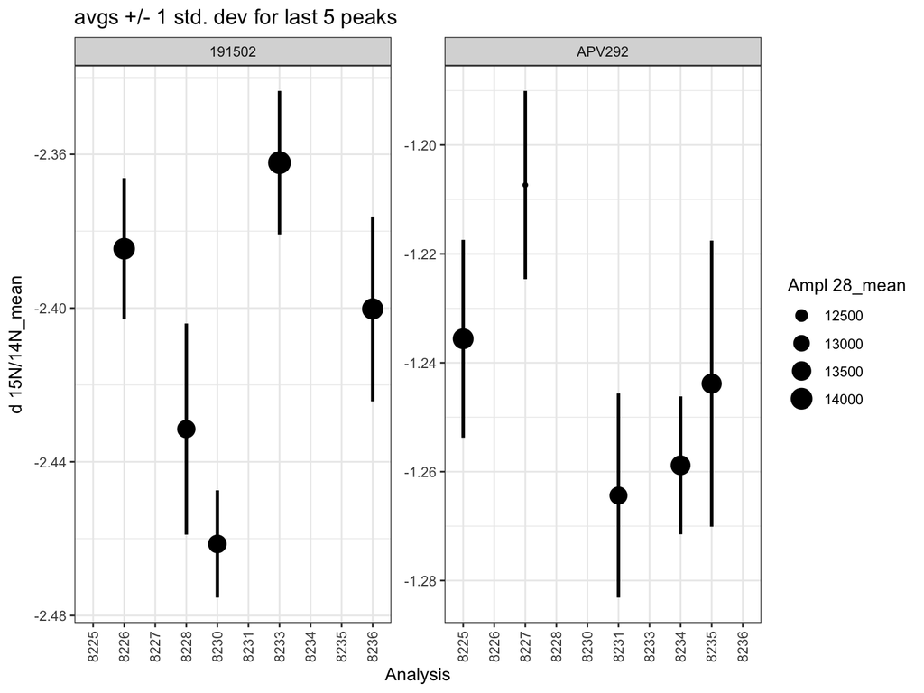

```r
# visualize mean and error of the measured standard (191502) and N2 gas used in the experiment (APV292)
data %>%
  filter(is.na(`Identifier 2`) | `Identifier 2` != "blank") %>%
  ggplot() +
  aes(Analysis, `d 15N/14N_mean`, size = `Ampl 28_mean`) +
  geom_errorbar(map = aes(ymax = `d 15N/14N_mean` + `d 15N/14N_sd`, ymin = `d 15N/14N_mean` - `d 15N/14N_sd`), width = 0, size = 1) +
  geom_point() +
  facet_wrap(~name, scales = "free_y") +
  theme_bw() +
  theme(axis.text.x = element_text(angle = 90, vjust = 0.5, hjust = 0)) +
  labs(title = "avgs +/- 1 std. dev for last 5 peaks")
```

```r
# numerical summary
data_summary <- data %>%
  filter(is.na(`Identifier 2`) | `Identifier 2` != "blank") %>%
  group_by(name) %>%
  summarize(
    n_analyses = n(),
    d15N = mean(`d 15N/14N_mean`),
    d15N_min = min(`d 15N/14N_mean`),
    d15N_max = max(`d 15N/14N_mean`),
    d15N_run_sd = sd(`d 15N/14N_mean`),
    d15N_analysis_max_sd = max(`d 15N/14N_sd`)
  )
data_summary
```

| name | n_analyses | d15N | d15N_min | d15N_max | d15N_run_sd | d15N_analysis_max_sd |
| --- | --- | --- | --- | --- | --- | --- |
| 191502 | 5 | -2.407962 | -2.461377 | -2.362172 | 0.03908451 | 0.02746966 |
| APV292 | 5 | -1.241999 | -1.264385 | -1.207355 | 0.02252303 | 0.02627592 |

## 3.5 Calibration

```r
N2_data <- data_frame(
  # known reference values of 191502
  d15_known_vs_air = -1.9,
  d15_known_vs_air.sigma = 0.3,
  # calculate means and errors of each N2
  d15_meas_std = filter(data_summary, name == "191502")$d15N,
  d15_meas_std.sigma = filter(data_summary, name == "191502")$d15N_run_sd,
  d15_meas_x = filter(data_summary, name == "APV292")$d15N,
  d15_meas_x.sigma = filter(data_summary, name == "APV292")$d15N_run_sd
) %>%
  mutate(
    eps_x_vs_std = (d15_meas_x - d15_meas_std) / (d15_meas_x/1000 + 1),
    val_temp = (1 + d15_known_vs_air/1000) * (1 + d15_meas_x/1000) / (1 + d15_meas_std/1000),
    err_temp = abs(val_temp) * sqrt( (d15_known_vs_air.sigma/(d15_known_vs_air + 1000))^2  + (d15_meas_std.sigma/(d15_meas_std + 1000))^2 + (d15_meas_x.sigma/(d15_meas_x + 1000))^2 ),
    err2_temp = abs(val_temp) * sqrt( (0/(d15_known_vs_air + 1000))^2  + (d15_meas_std.sigma/(d15_meas_std + 1000))^2 + (d15_meas_x.sigma/(d15_meas_x + 1000))^2 ),
    d_x_vs_air = (val_temp - 1)*1000,
    d_x_vs_air.sigma_prec = 1000*err_temp,
    d_x_vs_air.sigma_abs = 1000*err2_temp
  ) %>% select(-val_temp, -err_temp, -err2_temp)

N2_data
```

| d15_known_vs_air | d15_known_vs_air.sigma | d15_meas_std | d15_meas_std.sigma | d15_meas_x | d15_meas_x.sigma | eps_x_vs_std | d_x_vs_air | d_x_vs_air.sigma_prec | d_x_vs_air.sigma_abs |
| --- | --- | --- | --- | --- | --- | --- | --- | --- | --- |
| -1.9 | 0.3 | -2.407962 | 0.03908451 | -1.241999 | 0.02252303 | 1.167413 | -0.7334437 | 0.3037286 | 0.04517228 |

# 4 Fractionation factors ($\epsilon$)

Calculate the resulting fractionation factors of the biomass N vs. source N2 and aggregate all information for the isotope data table.

## 4.1 Analytical precision and error propagation

```r
# max. predicted analytical error
Norg_pred_se <-
  data_frame(
    name = "pred. analytical precision",
    prec_permil = max(data_d15N_org$true_d15N_pred_se)
  )
# std. deviation of the standards
Norg_stds_sd <- data_calibrated %>% filter(name %in% c("acetanilide1", "acetanilide2")) %>%
  group_by(name) %>%
  summarize(prec_permil = sd(true_d15N_pred))

# all 3 error estimates
bind_rows(
  Norg_pred_se,
  Norg_stds_sd
)
```

| name | prec_permil |
| --- | --- |
| pred. analytical precision | 0.11621080 |
| acetanilide1 | 0.08543499 |
| acetanilide2 | 0.10274195 |

```r
# --> use the most conservative one (predicted analytical precision from the calibration)
Norg_precision <- Norg_pred_se$prec_permil
message("Estimated analytical precision for Norg: ", signif(Norg_precision, 2), " permil")
```

```
#> Estimated analytical precision for Norg: 0.12 permil
```

```r
N2_precision <- N2_data$d_x_vs_air.sigma_abs
message("Estimated analytical precision for N2: ", signif(N2_precision, 2), " permil")
```

```
#> Estimated analytical precision for N2: 0.045 permil
```

```r
# propagated error to epsilons
eps_analytical_sigma <- sqrt(Norg_precision^2 + N2_precision^2)
message("Estimated analytical precision for epsilon Norg/N2 values: ", eps_analytical_sigma)
```

```
#> Estimated analytical precision for epsilon Norg/N2 values: 0.124681531161789
```

## 4.2 Export summary data table

```r
summary <-
  data_d15N_org %>%
  mutate(eps = ((true_d15N_pred/1000 + 1)/(N2_data$d_x_vs_air/1000 + 1) - 1) * 1000) %>%
  select(organism = run, pN2, replicate, eps) %>%
  mutate(eps_sigma_analytical = eps_analytical_sigma, eps_sigma_absolute = N2_data$d15_known_vs_air.sigma)

# printout
summary
```

| organism | pN2 | replicate | eps | eps_sigma_analytical | eps_sigma_absolute |
| --- | --- | --- | --- | --- | --- |
| A. cylindrica | 0.1 | 1 | -1.119593 | 0.1246815 | 0.3 |
| A. cylindrica | 0.1 | 2 | -1.098854 | 0.1246815 | 0.3 |
| A. cylindrica | 0.1 | 3 | -1.214517 | 0.1246815 | 0.3 |
| A. cylindrica | 0.1 | 4 | -1.185334 | 0.1246815 | 0.3 |
| A. cylindrica | 0.3 | 1 | -1.064070 | 0.1246815 | 0.3 |
| A. cylindrica | 0.3 | 2 | -1.410680 | 0.1246815 | 0.3 |
| A. cylindrica | 0.3 | 3 | -1.414700 | 0.1246815 | 0.3 |
| A. cylindrica | 0.3 | 4 | -1.327414 | 0.1246815 | 0.3 |
| A. cylindrica | 0.5 | 1 | -1.545277 | 0.1246815 | 0.3 |
| A. cylindrica | 0.5 | 2 | -1.501635 | 0.1246815 | 0.3 |

[output cut: 17 more lines]

```r
# export
summary %>% openxlsx::write.xlsx(file.path("data", "2018_Silverman_et_al-isotope_data.xlsx"))
```